# Recherche dichotomique

## Principe

La **dichotomie** est un mot d'origine greque qui signifie "diviser en deux".

La recherche d'une valeur par dichotomie dans un tableau peut être facilitée si celui-ci est trié. Dans ce cas, on divise successivement le tableau en 2 jusqu'à atteindre la valeur cherchée.

### Algorithme

Voici une écriture de l'algorithme de recherche dichotomique dans un **tableau trié** :

- `t` désigne un tableau trié
- `v` est la valeur cherchée dans le tableau
- `a`, `b` et `m` sont les indices de position des valeurs dans le tableau.

```
# a et b sont les indices de la première et dernière valeur du tableau t
a = 0
b = dimension(t) (nombre d'éléments - 1)

tant que a <= b:
    m = (a+b)//2 (m est l'indice de la valeur médiane du tableau t)
    si v < t[m]:
        b=m-1 (v se trouve dans la première moitié du tableau t entre les indices 0 et m-1)

    sinon si v > t[m]:
        a = m+1  (v se trouve dans la seconde moitié du tableau entre les indices m+1 et b)

    sinon:
        la valeur est trouvée et a pour indice m

# on sort de la boucle, la valeur n'est pas trouvée
```

### Remarque

En python, cet algorithme peut s'écrire sous forme d'une fonction qui renvoie un booléen : `True` si la valeur est dans le tableau, `False` sinon.

#### Exemple

Soit `t=[5, 9, 12, 14, 15, 16, 19, 20, 23, 25]` un tableau trié. On cherche la valeur 12.

- `a = 0` et `b = 9` donc `a < b`, on entre dans la boucle tant que ;
- on calcule la valeur de l'indice situé au milieu du tableau: `m = (0+9)//2 = 4`;
- La valeur cherchée `12 < t[4] = 15` donc la valeur cherchée est entre les indices `a = 0` et `b = m-1 = 3`.

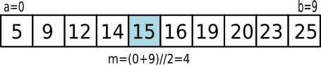

- `a = 0` et `b = 3` donc `a < b`, on reste dans la boucle tant que;
- on calcule la valeur de l'indice situé entre les indices 0 et 3: `m=(0+3)//2=1`;
- La valeur cherchée `12 > t[1] = 9` donc la valeur cherchée est entre les indices `a=m+1=2` et `b=3`.
- `a = 2` et `b = 3` donc `a < b`, on reste dans la boucle tant que;
- on calcule la valeur de l'indice situé entre les indices 2 et 3: `m=(2+3)//2=2`;
- La valeur cherchée `12 = t[2]` donc la valeur est trouvée en indice 2.

### Exercice

1. La fonction `rech_dicho` prend en paramètre un tableau trié de nombres et un nombre. Cette fonction renvoie un booléen indiquant la présence ou non du nombre cherché dans le tableau.  
   Coder en python la fonction `rech_dico`.
2. Tester votre fonction avec le tableau de nombres donné dans l'exemple ci-dessus.
3. Créer par compréhension un tableau trié de 100 nombres, négatifs et positifs, rangés par ordre croissant. Les valeurs pourront être choisies aléatoirement.
4. Appliquer la recherche dichotomique du nombre 0 dans votre tableau de 100 nombres.
5. Donner un écriture récursive de la fonction de recherche dichotomique.

## Terminaison de l'algorithme

### Variant de boucle

On appelle **variant de boucle** une quantité entière qui:

- doit être positive ou nulle pour rester dans la boucle;
- décroit strictement à chaque itération

Si on trouve une telle quantité dans une boucle while, celle-ci se termine.

### Preuve de la terminaison

   Le nombre `b - a` est strictement positif dans la boucle `while`.
1. Vérifions que le nombre `b - a` décroît:
- soit c'est l'indice `a` qui augmente et donc le nombre `b - a` diminue;
- soit c'est le nombre `b` qui diminue et donc le nombre `b - a` diminue.

En conclusion, le nombre `b - a` est un variant de boucle positif qui décroit, assurant la terminaison de la boucle `while`.

## Complexité de l'algorithme

La recherche dichotomique s'applique sur une liste triée de nombres.

Au départ, on compare le nombre cherché N avec la valeur du nombre M situé au milieu de la liste.

- Si N<M, alors on cherche le nombre N dans la première moitié de la liste.
- Si N>M, alors on cherche le nombre N dans la seconde moitié de la liste.

On recommence le processus en divisant chaque sous-liste jusqu'à obtenir une liste d'un nombre dans le pire des cas.

#### Exemple

Pour une liste de 20 nombres, en supposant le pire des cas, c'est à dire que le nombre n'est pas dans la liste.

On cherche successivement dans un liste de longueur 20, puis une liste de longueur 9, puis de longueur 4, puis une liste de longueur 2 ou une liste à 1 élément.

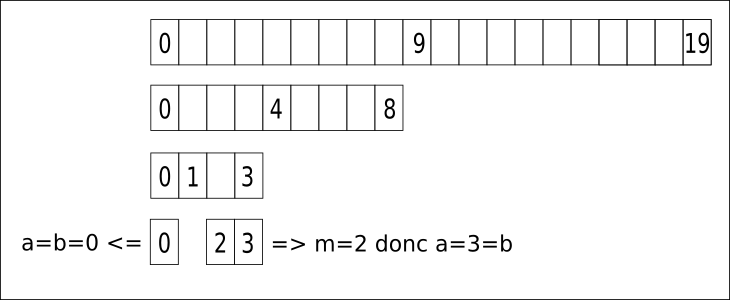

### Cas général

Supposons un tableau trié de dimension n (c'est à dire avec n nombres) :

Soit p le nombres de comparaisons nécessaires dans le pire des cas. Alors :

$2^{p} \geqslant n$ donc $\log_{2}(2^{p}) \geqslant \log_{2}(n)$ donc $p \times \log_{2}(2) \geqslant \log_{2}(n)$ donc $p \geqslant \log_{2}(n)$ car $\log_{2}(2)=1$.

Donc $p$ est supérieur ou égal à $\log_{2}(n)$.

La complexité de l'algorithme de recherche dichotomique est logarithmique : $O(\log_{2}(n))$.

### Remarques

1. Pour un tableau de 100 nombres, $p$ sera proche de $\log_{2}(100)\approx 6,64$, donc dans le pire des cas, on pourra déterminer si le nombre est dans la liste ou non en 7 tours de boucle `while`.
2. Pour un tableau trié de 1 million de nombres, le nombre maximum de tours de boucle sera de l'ordre de $\log_{2}(n) \approx 20$, soit 20 tours de boucles.
3. On peut comparer les complexités des algorithmes : $O(\log_{2}(n)) < O(n) < O(n^2)$

```python
from math import log2
```

```python
log2(2)
```

```
1.0
```

```python
log2(1E6)
```

```
19.931568569324174
```